# Domain expertise and scientific reading

An exploratory PoTeC analysis with lme4

Author

Analysis produced with the lme4-mixed-models skill

Published

September 27, 2026

## Purpose and interpretation

This analysis asks whether reading one’s own discipline rather than the other discipline is associated with different first-pass reading behavior, whether that contrast differs between undergraduate and graduate readers, and whether domain match modifies sensitivity to surprisal. Word length and lexical frequency are included as additional lexical predictors.

This is an **exploratory, informed trial of a statistical skill**. The analyst had seen the proposed evaluation criteria. There is no no-skill comparison and no basis for estimating the skill’s causal benefit from this run. The scientific analysis itself is observational: discipline and study level were not randomized.

The continuous analysis uses 95,683 fixated-word observations (full word sample). The binary analysis uses 33,600 word opportunities (quarter word sample). Both preserve all 75 readers and 12 texts. The sampled-word fits use a seeded quarter of eligible word tokens within every text, shared across readers. They must not be described as full-data analyses.

## Findings

The clearest pattern in this specification is a modest own-discipline reading-time advantage among graduate readers. At the reference lexical profile, the equally discipline-weighted own-minus-other contrast is **−0.0299 log milliseconds** (unadjusted 95% interval −0.0424 to −0.0174; twelve-test Holm-adjusted *p* = 0.00034). Exponentiating this log-scale contrast gives a geometric-mean ratio of about **0.971**, or **2.95% lower** first-pass reading time given fixation. This ratio is not an unqualified population arithmetic-mean effect.

For undergraduates, the corresponding estimate is −0.00785 log milliseconds (95% interval −0.0234 to 0.00773). The graduate-minus-undergraduate difference in domain-match contrasts is −0.0220 (95% interval −0.0427 to −0.00139), but its Holm-adjusted *p* is **0.379**. The result therefore does not establish that the domain-match advantage differs by study level under the declared comparison family. One individually small p-value and one individually large p-value would not establish that difference either.

The graduate own-minus-other difference in surprisal slope is −0.0149 log milliseconds per surprisal SD (95% interval −0.0256 to −0.00423), with adjusted *p* = **0.073**. The graduate-versus-undergraduate difference in this slope contrast has adjusted *p* = 1. These results do not establish study-level moderation of the expertise–surprisal association. They are also not equivalence tests.

None of the sampled-word FPReg model’s six exploratory Wald contrasts has a small adjusted p-value. However, the joint derivative check timed out; these approximate inferences are **numerically unqualified**, so this is not a validated negative finding. Its outcome is regression per eligible word opportunity, not regression conditional on fixation. The response curves illustrate a substantial distinction between zero-random-effect and integrated probabilities, but their point differences should not be interpreted without the uncertainty and sampling limits.

**Adequacy limits matter here.** The log-FPRT residual Q–Q plot has heavier tails than a Gaussian distribution, and standardized residual SD varies from about 0.89 to 1.17 across fitted-value deciles. Adjacent-word residual correlation is small (0.0145 over 63,931 eligible pairs), but that alone does not validate the residual model. The GLMM’s conditional simulation checks place its observed adjacent residual correlation and reader–text rate spread inside the simulated 95% ranges; these limited in-sample checks do not establish overall adequacy.

All fitted covariance specifications were singular. The same-row correlated reader/item LMM sensitivity, evaluated on the quarter-word sample, changed the six focal point estimates by less than 0.19 baseline standard errors, but its Hessian is indefinite. That is limited evidence of point-estimate stability, not a clean robustness pass. It does not replace a full-data covariance sensitivity. The stricter full-data LMM changed the focal contrasts by less than 0.00001 standard errors. Additional numerical audit results are shown below.

The explicit GLMM derivative calculation reached its 900-second limit without returning a Hessian. The warm-start alternative LMM optimizer reached its 600-second limit without returning a fit. These are recorded incomplete checks, not successes. The GLMM’s reported exploratory standard errors use lme4’s RX/PIRLS approximation, not the unavailable joint Hessian. The full LMM’s strict refit supports point-estimate stability but retains some scaled-gradient concerns.

The appropriate conclusion is an **exploratory own-domain reading-time association among graduate readers, with unresolved covariance/adequacy qualifications**. This is not a causal effect of training, a validated population prediction, or a confirmatory result about how expertise changes surprisal processing. The LMM remains under `SINGULAR_REVIEW` with Gaussian adequacy concerns; full numerical qualification remains `NUMERICAL_UNRESOLVED` for the LMM, GLMM and covariance sensitivity. This run is not assigned `READY_WITH_LIMITS`.

This bounded trial did not complete a full-corpus GLMM, a GLMM covariance sensitivity, a fixation-conditioned FPReg sensitivity, leave-text-out influence fits, or refit-based intervals propagating variance-component uncertainty. Those omissions limit the scientific claims made here.

## Data provenance and the observation unit

The inputs come from the [PoTeC repository](https://github.com/DiLi-Lab/PoTeC) and its linked OSF word-level reading-measures archive. Git revision 46247ca2aea5876311acf6b59338880d0bf5449d supplies the documentation and lexical features. The separately downloaded OSF archive has its own SHA-256 in `data-manifest.json`; the Git revision alone does not pin that archive. The repository records a surprisal correction on June 17, 2026. Every selected surprisal value in the archive was checked against the corrected pinned features.

The audit found **142,125 unique reader × text × word-position observations**, 75 readers and 1,895 word tokens. The roughly 404,000 count discussed in the benchmark proposal belongs to a different, scanpath-level table. Treating fixation-level repetitions as independent word outcomes would change the unit of analysis.

**Show R code**

```r
tab(fread(file.path(out,"data_counts.csv")))
```

| rows | missing_frequency | skipped | first_pass_fixated | regressions |
| --- | --- | --- | --- | --- |
| 142125 | 8625 | 38408 | 103717 | 23065 |

**Show R code**

```r
tab(fread(file.path(out,"reader_groups.csv")))
```

| reader_discipline_numeric | level_of_studies_numeric | readers |
| --- | --- | --- |
| 1 | 1 | 20 |
| 1 | 0 | 12 |
| 0 | 1 | 27 |
| 0 | 0 | 16 |

The upstream merge script fills missing lexical features with zero. The pinned original word-feature files identify 115 words with unavailable lemma frequency, corresponding to 8,625 reader–word rows. These were restored to missing and excluded from this complete-covariate pilot. The remaining set has 133,500 binary-outcome rows and 95,683 first-pass-fixated rows. This restriction changes the word population; it is not evidence that lexical missingness is ignorable.

The analysis uses text-context GPT-2-large surprisal, chosen before fitting. Log frequency, word length and surprisal are centered and scaled using **unique eligible word tokens**, rather than the fixation-selected outcome rows.

**Show R code**

```r
tab(fread(file.path(out,"scaling.csv")))
```

| variable | center | scale |
| --- | --- | --- |
| W | 5.881 | 3.544 |
| F | 5.972 | 4.105 |
| S | 4.373 | 3.695 |

## Outcomes, design and estimands

For the LMM, the response is `log(FPRT)` among `FPF == 1` observations with strictly positive FPRT. The audit verified that positive FPRT agrees with FPF. Skipped words are not treated as zero-millisecond readings and no arbitrary constant is added before logging.

For the GLMM, FPReg is modeled over **all eligible word opportunities**, including zeros for words not fixated in the first pass. The audit verified that unfixated words have FPReg zero. This outcome combines fixation opportunity and regression propensity. It is different from the probability of regression conditional on first-pass fixation; the conditional analysis is a sensitivity target, not an interchangeable denominator.

**Show R code**

```r
tab(fread(file.path(out,"glmm_event_counts.csv")))
```

| reader_discipline | study_level | text_domain | readers | words | regressions | non_regressions |
| --- | --- | --- | --- | --- | --- | --- |
| Physics | Graduate | Biology | 20 | 4480 | 651 | 3829 |
| Physics | Graduate | Physics | 20 | 4480 | 812 | 3668 |
| Physics | Undergraduate | Biology | 12 | 2688 | 415 | 2273 |
| Physics | Undergraduate | Physics | 12 | 2688 | 474 | 2214 |
| Biology | Graduate | Biology | 27 | 6048 | 762 | 5286 |
| Biology | Graduate | Physics | 27 | 6048 | 1009 | 5039 |
| Biology | Undergraduate | Biology | 16 | 3584 | 488 | 3096 |
| Biology | Undergraduate | Physics | 16 | 3584 | 548 | 3036 |

Each of the eight factorial cells contains regressions and non-regressions. This rules out complete separation by those cells alone; it does not prove absence of separation along every continuous predictor combination.

Readers are crossed with word tokens. Tokens belong to texts. Multiple words also share a reader–text reading episode. Text domain and lexical covariates vary within readers; reader discipline and study level vary within word items. A by-word slope for word length or text domain would not represent within-word variation. The support audit is retained in `outputs/design_support.csv`.

Numeric contrasts are fixed before fitting: biology = −0.5 and physics = +0.5 for reader discipline `D` and text domain `T`; undergraduate = −0.5 and graduate = +0.5 for study level `L`. `S`, `F`, and `W` denote standardized surprisal, log lemma frequency and word length. `TS=T*S` and `DL=D*L` are explicit numeric random-effect columns.

For each study level, the domain-match estimand is

$$\Delta_l=\tfrac12\{\eta_{B,l,B}-\eta_{B,l,P}
+\eta_{P,l,P}-\eta_{P,l,B}\},$$

at the mean lexical profile. Reader disciplines receive equal weight, rather than their unequal sample proportions. We also estimate $\Delta_{graduate}-\Delta_{undergraduate}$, and the same three contrasts of the surprisal slope. These are linear-predictor contrasts: log milliseconds for the LMM and log odds for the GLMM. They are not probability differences.

## Model specification and computation

The fixed structure is

```r
D * L * T * S + (D * T) * (F + W)
```

This preserves the factorial hierarchy, includes study-level moderation of the expertise–surprisal relationship, and allows domain-match dependence of the length and frequency associations. Study-level moderation of length/frequency is outside this pilot’s fixed-effect specification.

The starting random structure is

```r
(1 + T + S + TS + W + F || reader) +
(1 + D + L + DL || item) +
(1 + D + L + DL || text) +
(1 | reader_text)
```

All double-bar predictors are numeric. This deliberately diagonal covariance structure is a pragmatic restriction in the recorded contrast/centering basis. It is not invariant to arbitrary recoding and is not claimed to be a maximal model. Reader domain and domain-by-surprisal slopes protect the central within-reader questions; item and text slopes represent reader-group variation within stimuli. Only 12 texts inform the text covariance components.

The LMM uses REML. The GLMM uses a binomial logit likelihood with Laplace approximation (`nAGQ=1`). Gradient and Hessian calculation was explicitly enabled; installed lme4 defaults can omit derivative checks for large models. No fixed-effect selection or significance-driven random-effect deletion was used. The analysis plan and bounded computational policy are in `analysis-plan.yml`.

**Show R code**

```r
audits <- data.frame(
  model=c("Log-FPRT LMM","FPReg GLMM"),
  observations=c(nobs(lmm),nobs(glmm)),
  elapsed_seconds=c(audit_lmm$elapsed_seconds,audit_glmm$elapsed_seconds),
  singular=c(audit_lmm$singular,audit_glmm$singular),
  optimizer_code=c(audit_lmm$optimizer_code,audit_glmm$optimizer_code),
  derivatives_available=c(audit_lmm$derivatives_available,audit_glmm$derivatives_available))
tab(audits)
```

| model | observations | elapsed_seconds | singular | optimizer_code | derivatives_available |
| --- | --- | --- | --- | --- | --- |
| Log-FPRT LMM | 95683 | 560.367 | TRUE | 0 | TRUE |
| FPReg GLMM | 33600 | 793.403 | TRUE | 0 | FALSE |

Optimizer exit codes are not adequacy certificates. The retained audits include warnings, `VarCorr`, `rePCA`, gradients and Hessian eigenvalues. Boundary estimates were retained and examined rather than removed until a warning disappeared.

Installed lme4 2.0.1 did not provide the singular GLMM’s derivatives despite `calc.derivs=TRUE`. The extra check reconstructs the same deviance function, verifies its objective against the fitted likelihood, and explicitly evaluates finite-difference derivatives. The original fit and original audit are preserved.

**Show R code**

```r
extra_path <- file.path(model_dir("glmm"),"explicit_derivatives.json")
if(file.exists(extra_path)) {
  extra <- jsonlite::read_json(extra_path,simplifyVector=TRUE)
  tab(data.frame(min_Hessian_eigenvalue=min(extra$hessian_eigenvalues),
    max_absolute_free_scaled_gradient=extra$max_abs_free_scaled_gradient,
    minimum_boundary_gradient=extra$minimum_boundary_gradient,
    elapsed_seconds=extra$elapsed_seconds),digits=6)
} else {
  cat("Explicit derivative check timed out after 900 seconds; no Hessian result is available. Numerical qualification remains unresolved.")
}
```

```
Explicit derivative check timed out after 900 seconds; no Hessian result is available. Numerical qualification remains unresolved.
```

**Show R code**

```r
tab(as.data.frame(VarCorr(lmm)),caption="Log-FPRT LMM variance components")
```

Log-FPRT LMM variance components

| grp | var1 | var2 | vcov | sdcor |
| --- | --- | --- | --- | --- |
| item | DL | NA | 0.000 | 0.001 |
| item.1 | L | NA | 0.000 | 0.000 |
| item.2 | D | NA | 0.004 | 0.064 |
| item.3 | (Intercept) | NA | 0.034 | 0.184 |
| reader_text | (Intercept) | NA | 0.002 | 0.039 |
| reader | F | NA | 0.001 | 0.031 |
| reader.1 | W | NA | 0.002 | 0.040 |
| reader.2 | TS | NA | 0.000 | 0.021 |
| reader.3 | S | NA | 0.001 | 0.022 |
| reader.4 | T | NA | 0.000 | 0.019 |
| reader.5 | (Intercept) | NA | 0.016 | 0.126 |
| text | DL | NA | 0.000 | 0.008 |
| text.1 | L | NA | 0.000 | 0.000 |
| text.2 | D | NA | 0.000 | 0.000 |
| text.3 | (Intercept) | NA | 0.000 | 0.015 |
| Residual | NA | NA | 0.198 | 0.445 |

**Show R code**

```r
tab(as.data.frame(VarCorr(glmm)),caption="FPReg GLMM variance components")
```

FPReg GLMM variance components

| grp | var1 | var2 | vcov | sdcor |
| --- | --- | --- | --- | --- |
| reader_text | (Intercept) | NA | 0.000 | 0.000 |
| item | DL | NA | 0.012 | 0.110 |
| item.1 | L | NA | 0.000 | 0.000 |
| item.2 | D | NA | 0.032 | 0.178 |
| item.3 | (Intercept) | NA | 0.736 | 0.858 |
| reader | F | NA | 0.008 | 0.087 |
| reader.1 | W | NA | 0.010 | 0.100 |
| reader.2 | TS | NA | 0.000 | 0.000 |
| reader.3 | S | NA | 0.000 | 0.000 |
| reader.4 | T | NA | 0.008 | 0.089 |
| reader.5 | (Intercept) | NA | 0.193 | 0.440 |
| text | DL | NA | 0.032 | 0.180 |
| text.1 | L | NA | 0.012 | 0.110 |
| text.2 | D | NA | 0.000 | 0.000 |
| text.3 | (Intercept) | NA | 0.026 | 0.161 |

The full coefficient tables below describe the recorded contrast basis. They are not substitutes for the planned domain-match contrasts.

**Show R code**

```r
fixed_table <- function(fit) {
  data.frame(term=names(fixef(fit)),estimate=unname(fixef(fit)),
             SE=sqrt(diag(as.matrix(vcov(fit)))),row.names=NULL)
}
tab(fixed_table(lmm),digits=4,caption="Log-FPRT LMM fixed coefficients")
```

Log-FPRT LMM fixed coefficients

| term | estimate | SE |
| --- | --- | --- |
| (Intercept) | 5.5147 | 0.0165 |
| D | 0.0532 | 0.0306 |
| L | 0.0205 | 0.0306 |
| T | 0.0022 | 0.0134 |
| S | 0.0642 | 0.0062 |
| F | -0.0090 | 0.0085 |
| W | 0.1580 | 0.0088 |
| D:L | -0.0434 | 0.0612 |
| D:T | -0.0377 | 0.0100 |
| L:T | -0.0060 | 0.0095 |
| D:S | -0.0011 | 0.0067 |
| L:S | -0.0092 | 0.0064 |
| T:S | -0.0195 | 0.0115 |
| D:F | 0.0014 | 0.0090 |
| D:W | 0.0026 | 0.0106 |
| T:F | 0.0223 | 0.0154 |
| T:W | 0.0110 | 0.0148 |
| D:L:T | -0.0441 | 0.0195 |
| D:L:S | -0.0017 | 0.0127 |
| D:T:S | -0.0178 | 0.0093 |
| L:T:S | -0.0067 | 0.0078 |
| D:T:F | 0.0380 | 0.0108 |
| D:T:W | -0.0094 | 0.0101 |
| D:L:T:S | -0.0240 | 0.0155 |

**Show R code**

```r
tab(fixed_table(glmm),digits=4,caption="FPReg GLMM fixed coefficients")
```

FPReg GLMM fixed coefficients

| term | estimate | SE |
| --- | --- | --- |
| (Intercept) | -2.0669 | 0.0840 |
| D | 0.1846 | 0.1123 |
| L | -0.0209 | 0.1161 |
| T | 0.2534 | 0.1303 |
| S | 0.0536 | 0.0561 |
| F | -0.1885 | 0.0771 |
| W | 0.1952 | 0.0773 |
| D:L | -0.0275 | 0.2295 |
| D:T | -0.0269 | 0.0752 |
| L:T | 0.1664 | 0.0955 |
| D:S | 0.0104 | 0.0413 |
| L:S | 0.0260 | 0.0369 |
| T:S | 0.0428 | 0.1122 |
| D:F | 0.0355 | 0.0592 |
| D:W | 0.0191 | 0.0597 |
| T:F | 0.3198 | 0.1528 |
| T:W | 0.2102 | 0.1527 |
| D:L:T | -0.0780 | 0.1770 |
| D:L:S | 0.1665 | 0.0740 |
| D:T:S | 0.0700 | 0.0825 |
| L:T:S | 0.0243 | 0.0698 |
| D:T:F | 0.1768 | 0.1109 |
| D:T:W | 0.1254 | 0.1094 |
| D:L:T:S | 0.1470 | 0.1400 |

## Planned contrasts and inference

The LMM uses Satterthwaite approximate t inference through `lmerTest`; the GLMM uses exploratory asymptotic Wald z inference with lme4’s RX/PIRLS covariance approximation. The explicit GLMM joint-Hessian calculation timed out, so these GLMM intervals and p-values are numerically unqualified and are retained for transparency, not as validated scientific inference. Satterthwaite/Kenward–Roger corrections are not applied to the logistic model. The twelve planned tests—six per outcome—form one Holm-adjusted family. The displayed 95% intervals are **unadjusted**. These are model-based approximations, not simulation-calibrated guarantees.

**Show R code**

```r
display_contrasts <- contrasts[,.(outcome,contrast,estimate,
  `95% interval`=sprintf("[%.4f, %.4f]",lower,upper),`Holm p`=p_holm)]
tab(display_contrasts,digits=4)
```

| outcome | contrast | estimate | 95% interval | Holm p |
| --- | --- | --- | --- | --- |
| lmm | Own - other: undergraduate | -0.0079 | [-0.0234, 0.0077] | 1.0000 |
| lmm | Own - other: graduate | -0.0299 | [-0.0424, -0.0174] | 0.0003 |
| lmm | Domain match: graduate - undergraduate | -0.0220 | [-0.0427, -0.0014] | 0.3792 |
| lmm | Surprisal slope, own - other: undergraduate | -0.0029 | [-0.0162, 0.0103] | 1.0000 |
| lmm | Surprisal slope, own - other: graduate | -0.0149 | [-0.0256, -0.0042] | 0.0729 |
| lmm | Surprisal domain match: graduate - undergraduate | -0.0120 | [-0.0275, 0.0035] | 1.0000 |
| glmm | Own - other: undergraduate | 0.0060 | [-0.1177, 0.1297] | 1.0000 |
| glmm | Own - other: graduate | -0.0329 | [-0.1360, 0.0701] | 1.0000 |
| glmm | Domain match: graduate - undergraduate | -0.0390 | [-0.2125, 0.1345] | 1.0000 |
| glmm | Surprisal slope, own - other: undergraduate | -0.0018 | [-0.1186, 0.1151] | 1.0000 |
| glmm | Surprisal slope, own - other: graduate | 0.0717 | [-0.0222, 0.1656] | 1.0000 |
| glmm | Surprisal domain match: graduate - undergraduate | 0.0735 | [-0.0637, 0.2107] | 1.0000 |

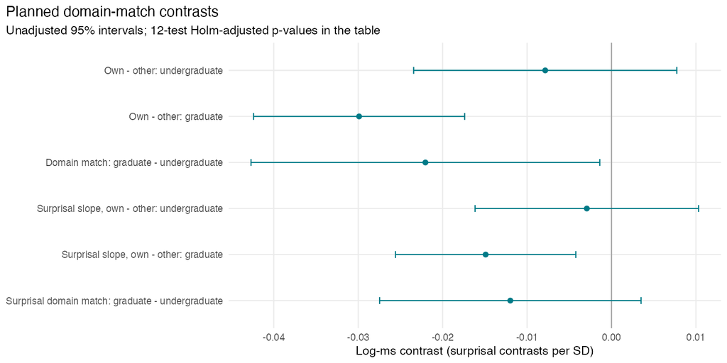

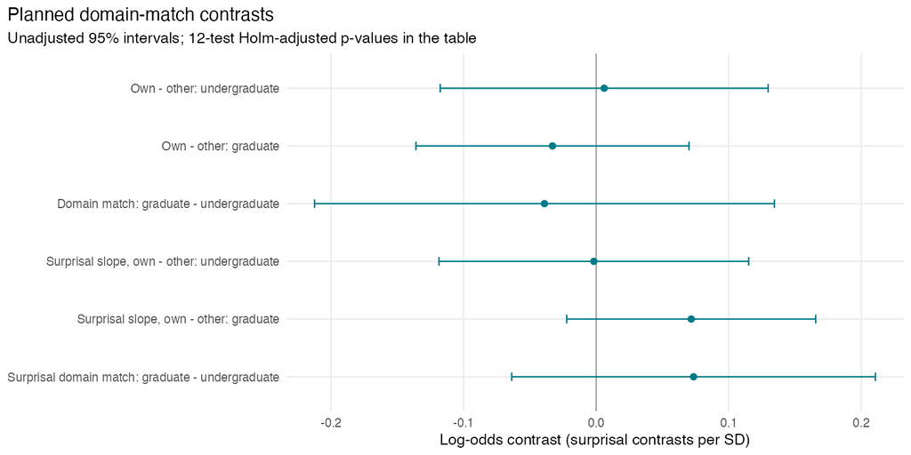

## Response scales and observed data

For new-group predictions, the variance of the random linear predictor is $v=zGz^\top$, summed across the fitted reader, item, text and reading-episode blocks. A lognormal arithmetic mean is $\exp(x\beta+(v+\sigma^2)/2)$. Simply exponentiating the log-scale expectation does not produce that mean.

For the GLMM, the new-group probability integrates $\operatorname{logit}^{-1}(x\beta+u)$ over $u\sim N(0,v)$. Gauss–Hermite quadrature was checked using two quadrature sizes and independent adaptive numerical integration. Setting random effects to zero instead yields $\operatorname{logit}^{-1}(x\beta)$, a distinct target.

The curves below show **plug-in point estimates**, with estimated variance components held fixed. They have no uncertainty ribbons and should not be read as precise population curves. The contrast plots above display fixed-effect uncertainty. A full interval for the integrated response mean would also need to propagate covariance-parameter uncertainty. Solid curves integrate over new-group heterogeneity; dashed curves set group effects to zero. For the LMM, both arithmetic-mean curves include residual lognormal retransformation.

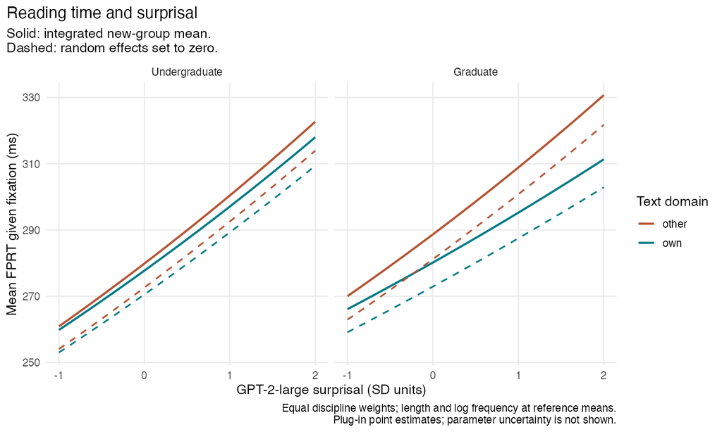

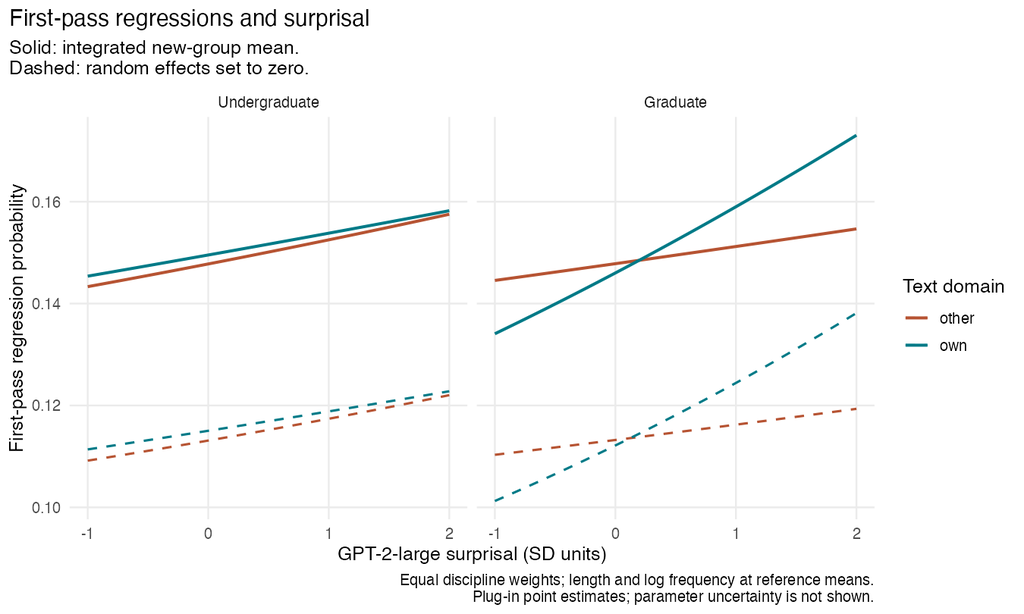

**Show R code**

```r
tab(predictions[abs(S)<1e-10,.(outcome,level,match,zero_RE,integrated)],digits=4)
```

| outcome | level | match | zero_RE | integrated |
| --- | --- | --- | --- | --- |
| lmm | Undergraduate | own | 270.5590 | 277.7482 |
| lmm | Undergraduate | other | 272.6386 | 279.8830 |
| lmm | Graduate | own | 272.9473 | 280.1999 |
| lmm | Graduate | other | 281.2337 | 288.7065 |
| glmm | Undergraduate | own | 0.1150 | 0.1495 |
| glmm | Undergraduate | other | 0.1131 | 0.1478 |
| glmm | Graduate | own | 0.1122 | 0.1460 |
| glmm | Graduate | other | 0.1132 | 0.1478 |

Observed reader summaries provide context without treating thousands of words as independent reader replicates. These raw means mix lexical profiles and are not the same estimands as the adjusted reference-profile predictions.

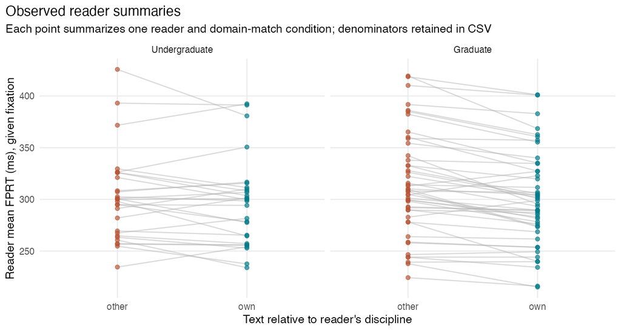

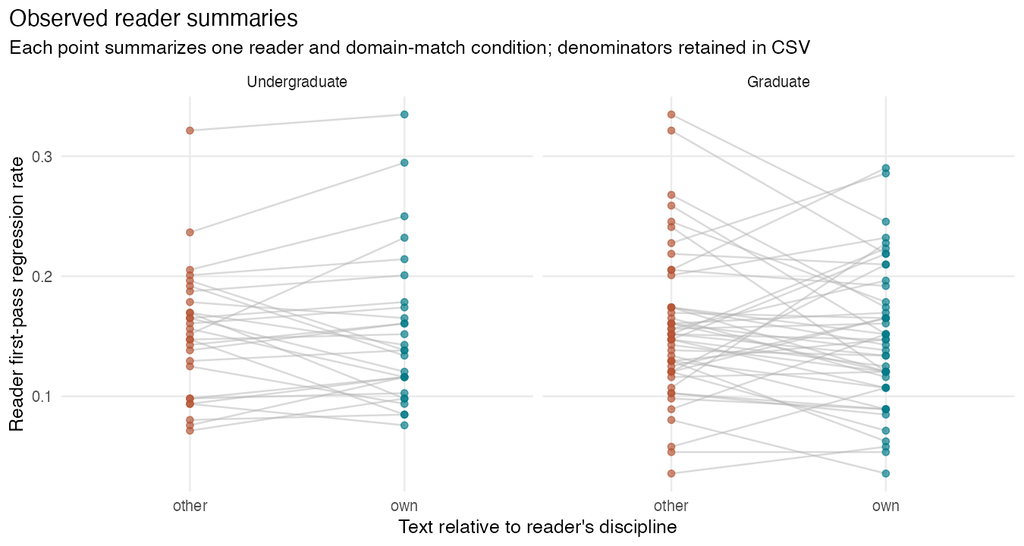

## Adequacy and sensitivity

**Show R code**

```r
tab(diagnostics,digits=4)
```

| outcome | adjacent_pairs | adjacent_residual_correlation | residual_sd_min | residual_sd_max | min_conditional_prediction | max_conditional_prediction |
| --- | --- | --- | --- | --- | --- | --- |
| lmm | 63931 | 0.0145 | 0.8873 | 1.1710 | 4.6323 | 7.9143 |
| glmm | 6675 | -0.0223 | 0.6214 | 1.0276 | 0.0066 | 0.8435 |

**Show R code**

```r
tab(fread(file.path(model_dir("glmm"),"conditional_simulation_checks.csv")),digits=4)
```

| statistic | observed | simulated_lower | simulated_upper | nsim | mode |
| --- | --- | --- | --- | --- | --- |
| adjacent | -0.0223 | -0.0239 | 0.0232 | 200 | Conditional on beta and all fitted random effects; no refitting |
| group_rate_sd | 0.0821 | 0.0774 | 0.0838 | 200 | Conditional on beta and all fitted random effects; no refitting |

Adjacent-word residual pairs are formed only within a reader–text episode and only where original word positions differ by one. Gaps introduced by subsampling or missing covariates are not treated as adjacent words. Binary simulation checks use 200 Bernoulli simulations conditional on fitted fixed and random effects, without refitting. They probe residual structure at those fitted values; they do not validate generalization or calibrate inferential error rates. DHARMa was not installed, so these explicit checks are not labelled DHARMa results.

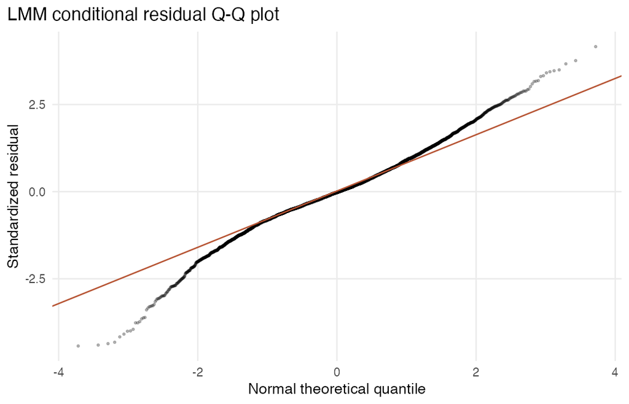

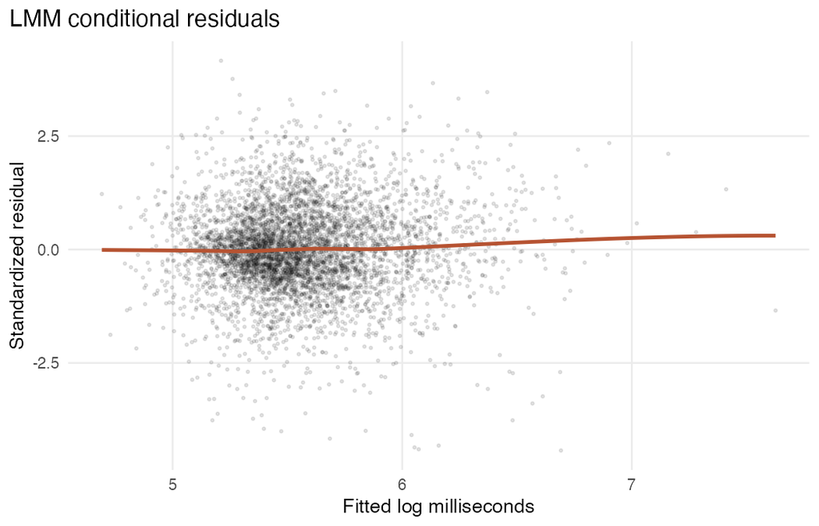

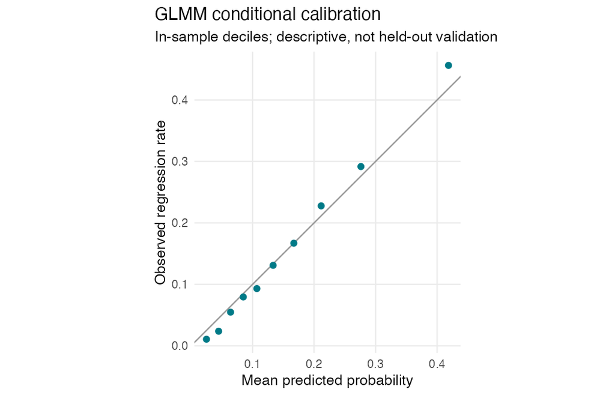

**Show R code**

```r
if(file.exists(file.path(out,"sensitivity_contrasts.csv"))) {
  sensitivity <- fread(file.path(out,"sensitivity_contrasts.csv"))
  tab(sensitivity[,.(model,contrast,estimate,`Shift / baseline SE`=shift_in_primary_SE)],digits=4)
} else {
  cat("Sensitivity results are documented in findings.md; no completed comparison table is available.")
}
```

| model | contrast | estimate | Shift / baseline SE |
| --- | --- | --- | --- |
| lmm-full-diagonal-strict | Own - other: undergraduate | -0.0079 | 0.0000 |
| lmm-full-diagonal-strict | Own - other: graduate | -0.0299 | 0.0000 |
| lmm-full-diagonal-strict | Domain match: graduate - undergraduate | -0.0220 | 0.0000 |
| lmm-full-diagonal-strict | Surprisal slope, own - other: undergraduate | -0.0029 | 0.0000 |
| lmm-full-diagonal-strict | Surprisal slope, own - other: graduate | -0.0149 | 0.0000 |
| lmm-full-diagonal-strict | Surprisal domain match: graduate - undergraduate | -0.0120 | 0.0000 |
| lmm-quarter-correlated-primary | Own - other: undergraduate | -0.0039 | 0.1258 |
| lmm-quarter-correlated-primary | Own - other: graduate | -0.0362 | -0.1197 |
| lmm-quarter-correlated-primary | Domain match: graduate - undergraduate | -0.0323 | -0.1806 |
| lmm-quarter-correlated-primary | Surprisal slope, own - other: undergraduate | 0.0035 | -0.0355 |
| lmm-quarter-correlated-primary | Surprisal slope, own - other: graduate | -0.0065 | -0.0241 |
| lmm-quarter-correlated-primary | Surprisal domain match: graduate - undergraduate | -0.0100 | 0.0139 |

Sensitivity fits are judged by focal estimate changes and numerical evidence, not by which produces smaller p-values. Correlated reader/item covariance is the prespecified structural alternative. A fixation-conditioned FPReg model, if completed, changes the outcome population and must be interpreted accordingly. Remaining sensitivity and adequacy limitations are stated in the findings.

## Reproduction and retained evidence

The document executes R to inspect retained fits and produce tables; expensive fitting is separated into scripts so rendering does not silently launch hours of refitting. The scripts and fitting formulas remain editable and reproducible:

```bash
python3 fetch_data.py
Rscript --vanilla prepare.R
Rscript --vanilla fit.R lmm full diagonal
Rscript --vanilla fit.R glmm quarter diagonal
Rscript --vanilla summarize.R full quarter
Rscript --vanilla sensitivity.R
quarto render analysis.qmd
```

Use the actual fit scopes and additional commands listed in `findings.md`. Existing downloaded inputs are retained; verify `data-manifest.json` before reuse. Re-running with a new download may produce different upstream bytes. The prose findings describe this frozen run; substantive refits require reviewing that interpretation as well as regenerating numerical tables. The raw log and JSON receipt for each controlled run retain its exit status, timing and command. No source skill or pre-existing repo edits were changed. The CSV contrast table also retains standard errors, denominator degrees of freedom, unadjusted p-values, interval limits and inference methods.

**Show R code**

## What this trial showed about the skill

The skill successfully prompted an explicit analysis contract before fitting, an audit of the observation unit, design-supported reader/item slopes, recorded contrast coding, separation of singularity from convergence, and explicit prediction targets. The data work found a consequential mismatch between the proposed observation count and the word-level table, and restored lexical missingness that the upstream merge had replaced by zeros.

Those are observed properties of this analyst’s run. They do not show that the same model without the skill would have failed, and some were already highlighted in the preceding conversation. This is not a measured skill improvement score.

The clearest weakness exposed by execution is the **numerical audit’s incomplete visibility into skipped checks**. With installed lme4 2.0.1, a singular GLMM fit returned no derivative matrix even with `calc.derivs=TRUE`; a singular fit also bypasses the usual convergence-check path. The skill’s helper reported singularity but did not specifically flag absent derivatives. A separate explicit derivative audit was needed; it exceeded its 900-second limit and did not complete. The correlated LMM sensitivity fit returned an indefinite Hessian despite an optimizer success code. These are concrete reasons to improve the audit’s evidence fields and stopping rules.

The trial also exposed a portability issue in the analysis code: converting a saved `lmerMod` to `lmerModLmerTest` initially failed because the recorded call referenced local data/formula/control objects. Rebinding the exact saved model frame corrected the reconstruction. The original failure log is retained.

The workflow was computationally expensive: a quarter-word GLMM required about 13 minutes, and the full LMM about 9 minutes, before all post-fit checks. A future skill revision would benefit from a staged runtime plan that preserves fitted objects before expensive checks, and explicit rules for reporting incomplete sensitivities. No change was made to the source skill during this trial.